# STAT 432 - Homework 03

Kevin Wong - kjwong2

Due:** Friday, February 16, 11:59 PM

Please see the [homework policy document](https://daviddalpiaz.github.io/stat432sp18/homework_policy.html) for detailed instructions and some grading notes. Failure to follow instructions will result in point reductions.

> “How did it get so late so soon?”

> — **Dr. Seuss**

For this homework we will again use the `Sacramento` data from the `caret` package. You should read the documentation for this data. The **goal** of our modeling will be to predict home prices.

You may only use the following packages:

```r
library(caret)
library(randomForest)
library(tidyverse)
library(knitr)
library(kableExtra)
```

Before modeling, we will perform some data preparation.

Instead of using the `city` or `zip` variables that exist in the dataset, we will simply create a variable indicating whether or not a house is technically within the city limits Sacramento. (We do this because they would both be factor variables with a large number of factors. This is a choice that is made due to laziness, not because it is justified. Think about what issues these variables might cause.)

```r
data(Sacramento)
sac_data = Sacramento
sac_data$limits = factor(ifelse(sac_data$city == "SACRAMENTO", "in", "out"))
sac_data = subset(sac_data, select = -c(city, zip))
```

A plot of longitude versus latitude gives us a sense of where the city limits are.

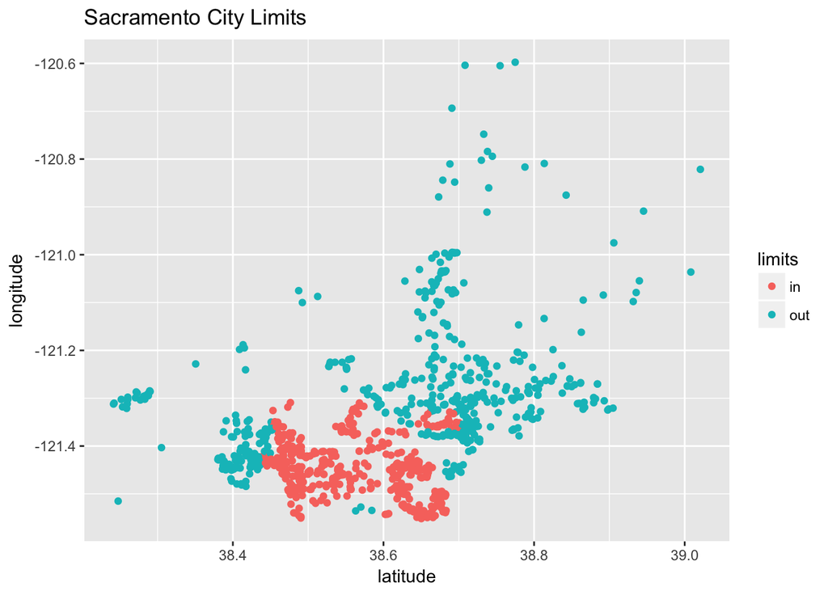

```r
qplot(y = longitude, x = latitude, data = sac_data,
      col = limits, main = "Sacramento City Limits ")
```

You should consider performing some additional [exploratory data analysis](https://en.wikipedia.org/wiki/Exploratory_data_analysis), but we provide a histogram of the home prices.

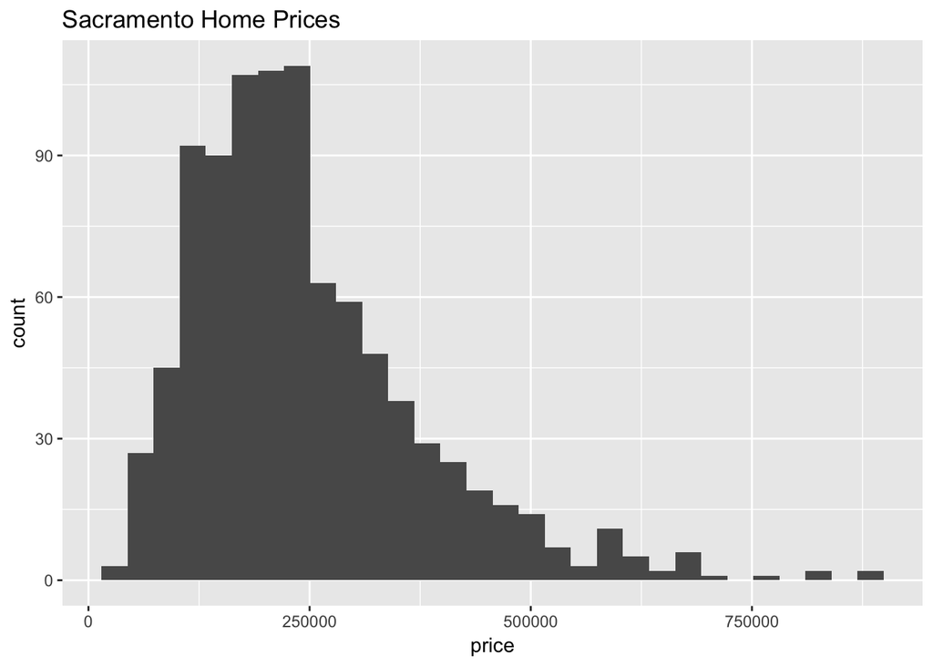

```r
qplot(x = price, data = sac_data, main = "Sacramento Home Prices")
```

After these modifications, we test-train split the data.

```r
set.seed(42)
sac_trn_idx  = sample(nrow(sac_data), size = trunc(0.80 * nrow(sac_data)))
sac_trn_data = sac_data[sac_trn_idx, ]
sac_tst_data = sac_data[-sac_trn_idx, ]
```

The training data should be used for all model fitting. Do not modify the data for any exercise in this assignment.

## Exercise 1 ($k$-Nearest Neighbors Preprocessing)

For this exercise, we will create $k$-nearest neighbors models in an attempt to be able to predict `price`. Do not modify `sac_trn_data`. Do not use the `baths` variable. Use the `knnreg` function from the `caret` package.

Consider three different preprocessing setups:

- **Setup 1**
  - Numeric variables not scaled.
  - Factor variables remain factors. `knnreg()` will use one-hot encoding.
- **Setup 2**
  - Numeric variables are scaled to have mean 0 and standard deviation 1.
  - Factor variables remain factors. `knnreg()` will use one-hot encoding.
- **Setup 3**
  - Numeric variables are scaled to have mean 0 and standard deviation 1.
  - Factor variables coerced to numeric. (We could then scale them, but for simplicity we will not.)

For each setup, train models using values of `k` from `1` to `100`. For each, calculate test RMSE. (In total you will calculate 300 test RMSEs, 100 for each setup.) Summarize these results in a single plot which plots the test RMSE as a function of `k`. (The plot will have three “curves,” one for each setup.) Your plot should be reasonably visually appealing, well-labeled, and include a legend.

**Solution:**

```r
tst_calc_rmse1 = rep(0, 100)
tst_calc_rmse2 = rep(0, 100)
tst_calc_rmse3 = rep(0, 100)

calc_rmse = function(mod, actual, data) {
  predicted = predict(mod, data)
  sqrt(mean((actual - predicted) ^ 2))
}
```

```r
for (i in 1:100) {
  knn_sac_mod_1 = knnreg(price ~ beds + sqft + type + latitude + longitude + limits, data = sac_trn_data, k = i)
  knn_sac_mod_2 = knnreg(price ~ scale(beds) + scale(sqft) + type + scale(latitude) + scale(longitude) + limits, data = sac_trn_data, k = i)
  knn_sac_mod_3 = knnreg(price ~ scale(beds) + scale(sqft) + as.numeric(type) + scale(latitude) + scale(longitude) + as.numeric(limits), data = sac_trn_data, k = i)

  tst_calc_rmse1[i] = calc_rmse(knn_sac_mod_1, sac_tst_data$price, sac_tst_data)
  tst_calc_rmse2[i] = calc_rmse(knn_sac_mod_2, sac_tst_data$price, sac_tst_data)
  tst_calc_rmse3[i] = calc_rmse(knn_sac_mod_3, sac_tst_data$price, sac_tst_data)
}
```

```r
tst_calc_rmse_total_ex1 = c(tst_calc_rmse1, tst_calc_rmse2, tst_calc_rmse3)
min(tst_calc_rmse_total_ex1)
```

```
## [1] 71250.62
```

```r
which.min(tst_calc_rmse_total_ex1)
```

```
## [1] 109
```

- The best model of the 300 is the `k = 9` of the `knn_sac_mod_2` model (`price ~ scale(beds) + scale(sqft) + type + scale(latitude) + scale(longitude) + limits`) because it has a Test RMSE of 7.125061610^{4}.

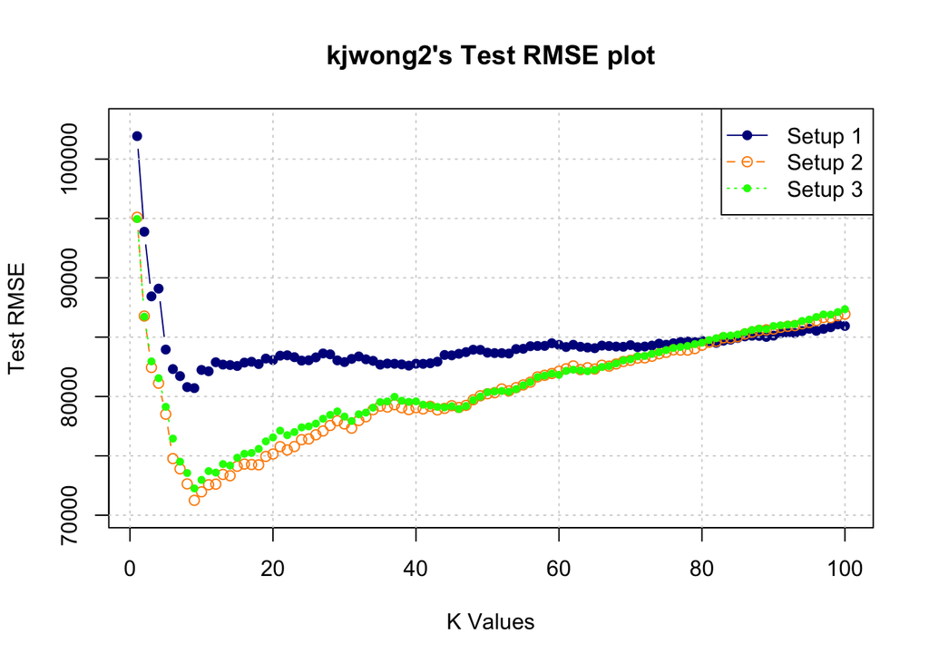

## Exercise 2 (Comparing Models)

For this exercise, we will create two additional models which we will compare to the best $k$-nearest neighbors model from the previous exercise. Again, do not modify `sac_trn_data` and do not use the `baths` variable.

Fit:

- A linear model using the formula: `price ~ . + sqft:type + type:limits - baths`
- A random forest that using all available predictors, excluding `baths`.

Create a well-formatted markdown table that displays the test RMSEs for these two models, as well as the best model from the previous exercise.

**Solution:**

```r
best_knn_mod_4 = knnreg(price ~ scale(beds) + scale(sqft) + type + scale(latitude) + scale(longitude) + limits, data = sac_trn_data, k = 9)
lm_sac_mod_5 = lm(price ~ . + sqft:type + type:limits - baths, data = sac_trn_data)
rf_sac_mod_6 = randomForest(price ~ . - baths, data = sac_trn_data)
```

```r
mod_ex2_list = list(best_knn_mod_4, lm_sac_mod_5, rf_sac_mod_6)
sac_ex2_trn_rmse = sapply(mod_ex2_list, actual = sac_trn_data$price, calc_rmse, data = sac_trn_data)
sac_ex2_tst_rmse = sapply(mod_ex2_list, actual = sac_tst_data$price, calc_rmse, data = sac_tst_data)
```

| Model Name | Training RMSE | Testing RMSE |
| --- | --- | --- |
| best_knn_mod_4 | 73372.19 | 71250.62 |
| lm_sac_mod_5 | 79304.28 | 72859.70 |
| rf_sac_mod_6 | 44787.43 | 67362.78 |

## Exercise 3 (Visualizing Results)

For each of the models in Exercise 2, create a **Predicted vs Actual** plot. Each plot should:

- Plot the predicted value ($y$-axis) versus the actual value in the test set ($x$-axis).
- Include a line indicating where $x = y$.
- Use a title indicating the model results being visualizing.
- Include some modification of default behavior to make the plot more visually appealing.

Arrange the three plots side-by-side in a single row.

**Solution:**

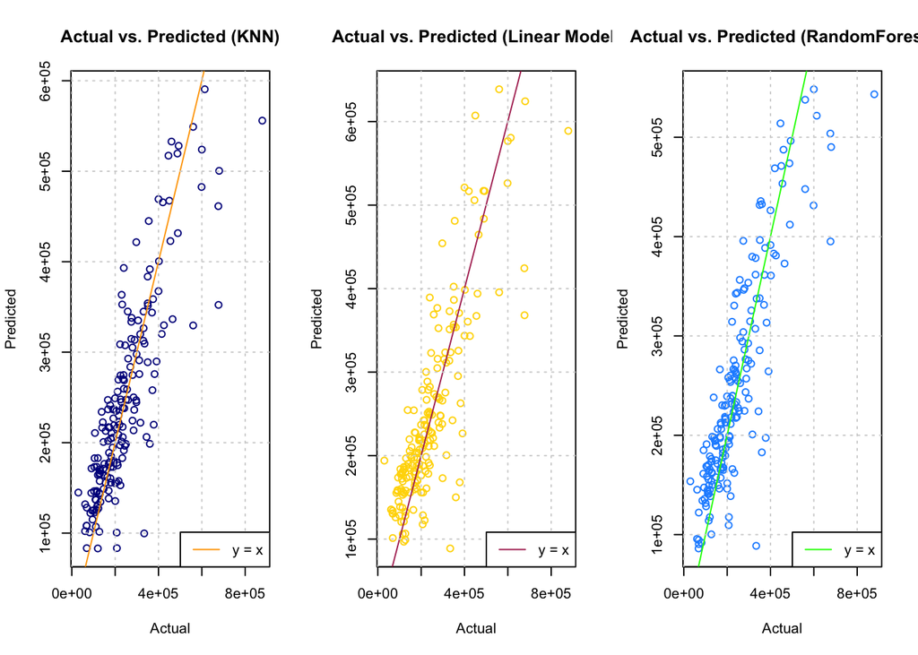

## Exercise 4 (Test-Train Split)

Repeat Exercise 1, but with the following train and test data. Again, summarize your results in a plot.

```r
set.seed(432)
sac_trn_idx_new  = sample(nrow(sac_data), size = trunc(0.80 * nrow(sac_data)))
sac_trn_data_new = sac_data[sac_trn_idx_new, ]
sac_tst_data_new = sac_data[-sac_trn_idx_new, ]
```

**Solution:**

```r
tst_calc_rmse7 = rep(0, 100)
tst_calc_rmse8 = rep(0, 100)
tst_calc_rmse9 = rep(0, 100)

for (i in 1:100) {
  knn_sac_mod_7 = knnreg(price ~ beds + sqft + type + latitude + longitude + limits, data = sac_trn_data_new, k = i)
  knn_sac_mod_8 = knnreg(price ~ scale(beds) + scale(sqft) + type + scale(latitude) + scale(longitude) + limits, data = sac_trn_data_new, k = i)
  knn_sac_mod_9 = knnreg(price ~ scale(beds) + scale(sqft) + as.numeric(type) + scale(latitude) + scale(longitude) + as.numeric(limits), data = sac_trn_data_new, k = i)

  tst_calc_rmse7[i] = calc_rmse(knn_sac_mod_7, sac_tst_data_new$price, sac_tst_data_new)
  tst_calc_rmse8[i] = calc_rmse(knn_sac_mod_8, sac_tst_data_new$price, sac_tst_data_new)
  tst_calc_rmse9[i] = calc_rmse(knn_sac_mod_9, sac_tst_data_new$price, sac_tst_data_new)
}
```

```r
tst_calc_rmse_total_ex4 = c(tst_calc_rmse7, tst_calc_rmse8, tst_calc_rmse9)
min(tst_calc_rmse_total_ex4)
```

```
## [1] 75550.75
```

```r
which.min(tst_calc_rmse_total_ex4)
```

```
## [1] 118
```

- The best model of the 300 is the `k = 18` of the `knn_sac_mod_8` model (`price ~ scale(beds) + scale(sqft) + type + scale(latitude) + scale(longitude) + limits`) because it has a Test RMSE of 7.555074710^{4}.

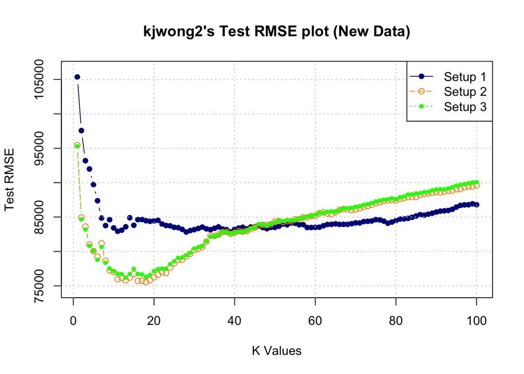

## Exercise 5 (Concept Checks)

**[a]** Which of the 300 models trained in Exercise 1 do you feel performs best?

**Solution:** - The best model of the 300 is the `k = 9` of the `knn_sac_mod_2` model.

**[b]** Based on your results for Exercise 1, do you feel that scaling the numeric variables was appropriate?

**Solution:**

```r
mean(tst_calc_rmse1)
```

```
## [1] 84214.69
```

```r
mean(tst_calc_rmse2)
```

```
## [1] 80653.06
```

- Yes, scaling the variables was appropriate because the mean Test RMSE of the first 100 models was higher than the second 100 models.

**[c]** Based on your results for Exercise 1, do you feel that the method used to utilize the factor variables had a large effect?

**Solution:**

```r
mean(tst_calc_rmse2)
```

```
## [1] 80653.06
```

```r
mean(tst_calc_rmse3)
```

```
## [1] 81029.91
```

**[d]** Based on your results for Exercise 2, which of these models do you prefer?

**Solution:** I prefer the Random Forest model (`rf_sac_mod_6`) because it has the lowest Test RMSE.

**[e]** Based on your results for Exercise 3, do you prefer a different model than part **[d]**? If so which and why?

**Solution:** - No, because the random Forest appears to be the most crowded along the line Y=X among the 3 plots.

**[f]** Based on your results for Exercise 4, do you prefer a different preprossesing setup for $k$-nearest neighbors? (Compared to your preference based on Exercise 1.) If so, which and why?

**Solution:**

```r
mean(tst_calc_rmse_total_ex1)
```

```
## [1] 81965.88
```

```r
mean(tst_calc_rmse_total_ex4)
```

```
## [1] 84114.37
```

- No, because the mean Test RMSE of the 300 models in Exercise 1 is lower than the mean Test RMSE of the 300 models in Exercise 4.

**[g]** Based on your results for Exercise 4, do you prefer a different value of $k$ for $k$-nearest neighbors? (Compared to your preference based on Exercise 1.) If so, which and why?

**Solution**

```r
which.min(tst_calc_rmse1)
```

```
## [1] 9
```

```r
which.min(tst_calc_rmse2)
```

```
## [1] 9
```

```r
which.min(tst_calc_rmse3)
```

```
## [1] 9
```

```r
which.min(tst_calc_rmse7)
```

```
## [1] 28
```

```r
which.min(tst_calc_rmse8)
```

```
## [1] 18
```

```r
which.min(tst_calc_rmse9)
```

```
## [1] 13
```